# Aula 10 - Econometria de Séries Temporais

João Ricardo F. de Lima

15 de maio de 2022.

# 1 Análise de Séries Temporais Multivariadas

Na análise univariada de séries temporais o objetivo era, basicamente, entender a dependência dinâmica de uma série $X_{t}$, isto é, a dependência de $X_{t}$ com os seus valores passados $(X_{t-1}, X_{t-2},...)$.

Contudo, existem variáveis que são definidas dentro de um sistema e é um erro modelar estes processos de maneira puramente autorregressiva ou não controlando a dinâmica intertemporal: PIB, Consumo, Investimento, Gastos do Governo são definidos simultaneamente, por exemplo.

Essas questões, bastante pertinentes no dia a dia, são tratadas dentro da **análise multivariada de séries temporais**.

São objetivos básicos da análise multivariada de séries temporais:

1. Estudar as relações dinâmicas entre séries diversas;
2. Melhorar as previsões sobre uma variável específica.

Seja $z_{t} = (z_{1t}, z_{2t}, ..., z_{kt})^{'}$ um vetor de dimensão $k$ que contém séries temporais observadas em um período de tempo comum. Por exemplo, $z_{1t}$ é o PIB trimestral brasileiro e $z_{2t}$ é a taxa de desemprego também trimestral.

Estudando $z_{1t}$ e $z_{2t}$ conjuntamente, pode-se verificar a dependência contemporânea e passada que existe entre essas duas variáveis. Pode-se verificar o quanto um choque no PIB afeta a taxa de desemprego e quanto tempo isso tende a durar. Pode-se estar interessados na relação entre os desembolsos do BNDES e a taxa de investimento da economia brasileira. Será que aumentar os desembolsos ao banco eleva o investimento no país?

## 1.1 Exemplo de séries que possuem correlação

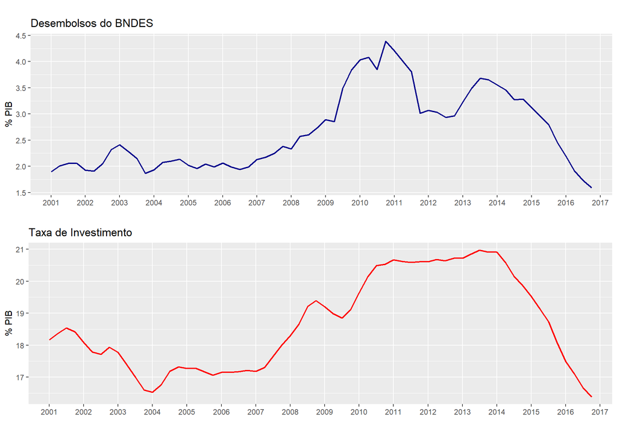

```r
library(vars)
library(aod)
library(urca)
library(stargazer)
library(forecast)
library(ggplot2)
#library(ggthemr)
library(gridExtra)
library(readxl)
library(scales)
#ggthemr('light')

# Os dados do BNDES estão em http://bit.ly/2pHg5wc. Depois de baixar e salvar na pasta correta, é importar os dados

setwd('C:/Users/Joao Ricardo Lima/Dropbox/tempecon/facape/econometria2')

data <- read_xls("bndes.xls", range = "AX5:AX264")
colnames(data) <- "desembolso"
data <- as.data.frame(data)

#Retira os valores faltantes
data <- na.omit(data)

#Retira os somatórios
data <- data[-c(13,13*2,13*3,13*4,13*5,13*6,13*7,13*8,13*9,13*10,13*11,
                13*12,13*13,13*14,13*15,13*16,13*17,13*18),]

data <- as.data.frame(data)

#Seta como série temporal
desembolso <- ts(data, start=c(2000,1), freq=12)

#Limita até o final de 2016
desembolso <- window(desembolso, end=c(2016,12))

anual <- desembolso
anual <- (anual+lag(anual,-1)+lag(anual,-2)+lag(anual,-3)+
              lag(anual,-4)+lag(anual,-5)+lag(anual,-6)+
              lag(anual,-7)+lag(anual,-8)+lag(anual,-9)+
              lag(anual,-10)+lag(anual,-11))
desembolso12 <- anual

# Dados do PIB e da taxa de investimento

data2 <- ts(read.csv2('data-1.csv', sep=';', dec=',')[,-1],
            start=c(1996,4), freq=4)

# Consolidando os dados
bndes <- ts(aggregate(desembolso12, nfrequency = 4, FUN=mean),
                start=c(2001,1), freq=4)

# Juntando as bases de dados
data <- ts.intersect(data2, bndes)
data <- cbind(data[,3]/data[,1]*100, data[,2])
colnames(data) <- c('BNDES', 'Investimento')

#Plot dos dois gráficos
g1 <- autoplot(data[,1])+
  geom_line(size=.8, colour='darkblue')+
  scale_x_discrete(limits=2001:2017)+
  labs(title='Desembolsos do BNDES')+
  xlab('')+ylab('% PIB')
g2 <- autoplot(data[,2])+
  geom_line(size=.8, colour='red')+
  scale_x_discrete(limits=2001:2017)+
  labs(title='Taxa de Investimento')+
  xlab('')+ylab('% PIB')
grid.arrange(g1, g2,
             top = "",
            layout_matrix = matrix(c(1,1,2,2),
                                   ncol=2, byrow=TRUE))
```

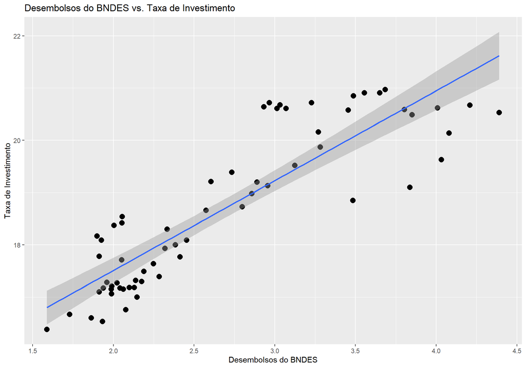

```r
# Correlação entre Desembolsos do BNDES vs. Taxa de Investimento
dates <- seq(as.Date('2001-01-01'), as.Date('2016-12-01'), by='3 month')
df <- data.frame(time=dates, bndes=data[,1], investimento=data[,2])
ggplot(df, aes(bndes, investimento))+
  geom_point(colour='black', size=5, shape=20)+
  geom_smooth(method = 'lm')+
  xlab('Desembolsos do BNDES')+
  ylab('Taxa de Investimento')+
  labs(title='Desembolsos do BNDES vs. Taxa de Investimento')
```

```r
cor(data)
```

```
#                  BNDES Investimento
# BNDES        1.0000000    0.8732192
# Investimento 0.8732192    1.0000000
```

A correlação entre as variáveis é 0.87, bastante elevada.

## 1.2 Modelos Multivariados

Contudo, não é o bastante para se identificar a natureza da relação entre elas. Algumas questões devem ser levadas em consideração. Suponha que as series sejam estacionárias em nível. Pode-se, nesse caso, estimar um **Vetor Autoregressivo (VAR)** de primeira ordem, de modo que:

$$FBCF_{t} = \delta_{1} + \gamma_{11}FBCF_{t-1} + \gamma_{12}BNDES_{t-1} +
\varepsilon_{1t}$$

$$BNDES_{t} = \delta_{2} + \gamma_{21}BNDES_{t-1} + \gamma_{22}FBCF_{t-1}
+ \varepsilon_{2t}$$

### 1.2.1 O Modelo VAR

O VAR(1) vai descrever a evolução dinâmica da interação entre a FBCF e os desembolsos do BNDES.

O modelo VAR foi desenvolvido por Christopher Sims em um artigo publicado em 1980 na qual se propunha tratar todas as variáveis do sistema simetricamente, sem fazer hipótese sobre a estrutura de correlação entre elas.

Uma vez estimado esse modelo, pode-se perguntar se existe causalidade nessa relação, isto é, se os desembolsos do BNDES de fato ajudam a prever a taxa de investimento, se o contrário ocorre ou se há uma simultaneidade. Nesse último caso, diz-se que existe uma causalidade bidirecional.

Para definir o modelo VAR pode-se apresentar uma especificação bivariada simples. A idéia é que não sabendo se há causalidade mútua, se parte de um modelo em que as inovações contemporâneas de um processo afetam o outro.

$$y_{1,t}=\alpha_1-\delta_2y_{2,t}+\beta_1y_{1,t-1}+\beta_2y_{2,t-1}+\epsilon_{1,t}$$

$$y_{2,t}=\alpha_2-\delta_1y_{1,t}+\beta_2y_{2,t-1}+\beta_1y_{1,t-1}+\epsilon_{2,t}$$

No sistema acima, os termos $y_{1,t}$ e $y_{2,t}$ representam a dinâmica contemporânea, relaxando a hipótese de restrição de *feedback*.

O modelo acima está no denominado modelo estrutural, devido a presença do termo contemporâneo no lado direito de cada equação.

Para colocá-lo na forma reduzida, se escreve o modelo na forma matricial a partir do rearranjo;

$$y_{1,t}+\delta_2y_{2,t}=\alpha_1+\beta_1y_{1,t-1}+\beta_2y_{2,t-1}+\epsilon_{1,t}$$

$$y_{2,t}+\delta_1y_{1,t}=\alpha_2+\beta_2y_{2,t-1}+\beta_1y_{1,t-1}+\epsilon_{2,t}$$
a partir do qual se obtém:

$$\left[\begin{array}{cc}
1 & \delta_2\\
\delta_1 & 1
\end{array}\right] \left[\begin{array}{c}
y_1 \\
y_2
\end{array}\right]_t = \left[\begin{array}{c}
\alpha_1\\
\alpha_2
\end{array}\right]+ \left[\begin{array}{cc}
\beta_1 & \beta_2 \\
\beta_2 & \beta_1
\end{array}\right] \left[\begin{array}{c}
y_1 \\
y_2
\end{array}\right]_{t-1}+\left[\begin{array}{c}
\epsilon_1 \\
\epsilon_2
\end{array}\right]_t$$

que pode ser simplificado como

$$Ay_t=\alpha+B^*y_{t-1}+\epsilon_t$$

se a equação acima for multiplicada pela inversa da Matriz A, ou seja,

$$A^{-1}=\left[\begin{array}{cc}
1 & \delta_2\\
\delta_1 & 1
\end{array}\right]^{-1}= \frac{1}{1-\delta_1\delta_2}\left[\begin{array}{cc}
1 & -\delta_1\\
-\delta_2 & 1
\end{array}\right]$$

De onde se obtém

$$y_t=a+By_{t-1}+e_t,$$

a chamada forma reduzida, em que $a=A^{-1}\alpha$, $B=A^{-1}B^*$ e $e_t=A^{-1}\epsilon_t$

No Modelo VAR todas as variáveis são consideradas endógenas e determinadas de forma dinâmica pelos valores defasados.

Se tem uma equação para cada variável em função de seus valores defasados e dos valores defasados das outras variáveis.

Um VAR tem duas dimensões: a) número de variáveis =k; b)número de defasagens =p.

O estimador de MQO pode ser aplicado a cada equação individualmente.

Um modelo VAR precisa ser estável. A estabilidade do VAR é definida pelas suas raízes características. Se o VAR não for estável, não tem sentido ser estimado.

A estabilidade de um VAR pode ser examinada calculando as raízes características de:

$$(I+B+B^2+ \dots+B^k)y_t=\sum_{i=0}^{\infty}B^i\epsilon_{t-1}$$

O polinômio característico é definido por

$$\Pi(z)=(I+B+B^2+ \dots+B^k)$$

As raízes de $|\Pi(z)|=0$ informarão sobre o processo ser ou não ser estacionário.

A condição necessária e suficiente para a estabilidade do VAR é que todas as raízes características estejam fora do círculo unitário.

Estacionariedade e estabilidade são duas propriedades fortemente relacionadas. No caso de modelos VAR, tal relação se dá pelo fato de que modelos VAR estáveis são sempre estacionários.

A negativa dessa informação não é verdadeira. Contudo, processos instáveis não tem interesse econômico.

Considere o modelo abaixo:

$$\left[\begin{array}{c}
y_1 \\
y_2
\end{array}\right]_t = \left[\begin{array}{c}
0.5\\
1.0
\end{array}\right]+ \left[\begin{array}{cc}
0.7 & 0.4 \\
0.2 & 0.3
\end{array}\right] \left[\begin{array}{c}
y_1 \\
y_2
\end{array}\right]_{t-1}+\left[\begin{array}{c}
\epsilon_1 \\
\epsilon_2
\end{array}\right]_t$$

Este processo está simulado na figura abaixo:

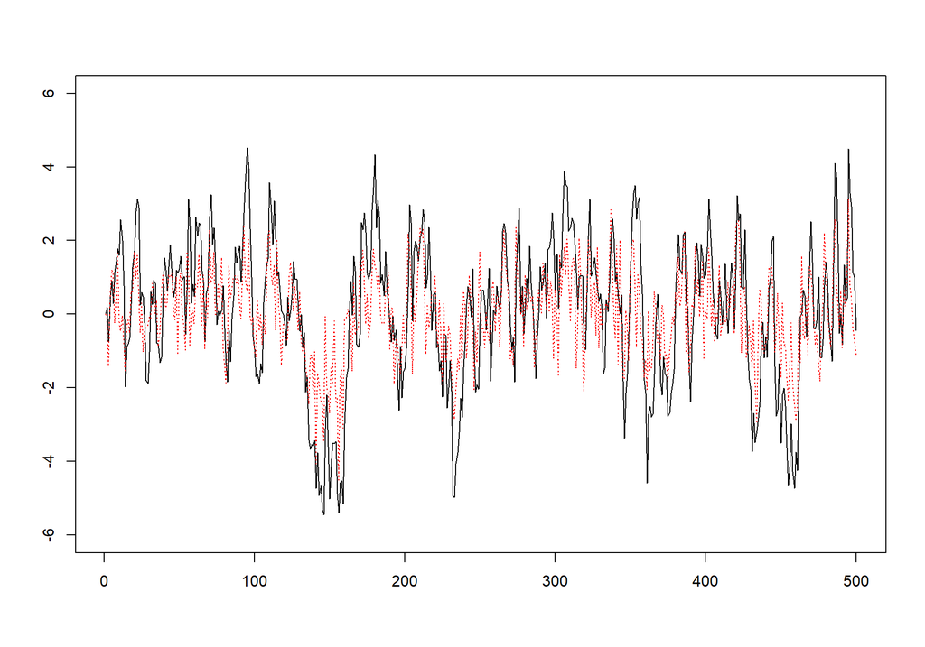

```r
# pacotes necessários
library(dse)

n <- 500
r <- 0.7
set.seed(1)
Z1 <- rnorm(n)
Z2 <- rnorm(n)

E1 <- Z1
E2 <- r*Z1 + sqrt(1-r^2)*Z2

A <- matrix(c(.7,.2,.4,.3),2,2)

y_1 = y_2 <- rep(0,n)
for(t in 2:n){
  y_1[t] <- A[1,1]*y_1[t-1] + A[1,2]*y_2[t-1] + E1[t]
  y_2[t] <- A[2,1]*y_1[t-1] + A[2,2]*y_2[t-1] + E2[t]
}

# Figura 8.1
plot(y_1, type = "l", lty = 1, ylim = c(-6,6), ann = FALSE)
lines(y_2,lty = 3, col = "red")
```

Estes processos apresentam dinâmica comum. É dito estável.

Para obter um processo não estável basta que as raízes sejam unitárias:

$$\left[\begin{array}{c}
y_1 \\
y_2
\end{array}\right]_t = \left[\begin{array}{cc}
1 & 0 \\
0 & 1
\end{array}\right] \left[\begin{array}{c}
y_1 \\
y_2
\end{array}\right]_{t-1}+\left[\begin{array}{c}
\epsilon_1 \\
\epsilon_2
\end{array}\right]_t$$

Este processo está simulado na figura abaixo:

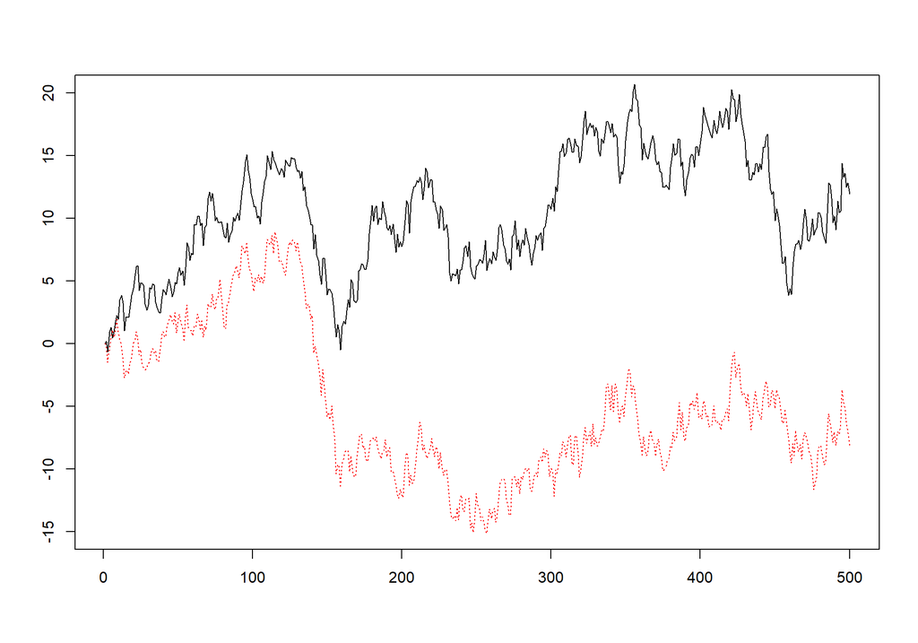

```r
# A outra  matriz "A" abaixo gera o processo do sistema (8.14).

A = matrix(c(1,0,0,1),2,2)

y_3 = y_4 <- rep(0,n)

for(t in 2:n){
   y_3[t] <- A[1,1]*y_3[t-1] + A[1,2]*y_4[t-1] + E1[t]
   y_4[t] <- A[2,1]*y_3[t-1] + A[2,2]*y_4[t-1] + E2[t]
}

# # Figura 8.2
plot(y_3, type = "l", lty = 1, ylim = c(-15,20), ann = FALSE)
 lines(y_4,lty = 3, col = "red")
```

Estes processos não apresentam dinâmica comum, tendem a se descolar. É dito instável.

### 1.2.2 Determinação da ordem de defasagem

Uma vez de posse dos nossos dados, já devidamente tratados, um problema imediato é determinar a ordem $p$ de defasagem do nosso modelo. Isso é feito empiricamente pela análise de **critérios de informação**. Os mais conhecidos são os critérios de Akaike, Hannan-Quinn e Schwarz, sendo determinado como se segue:

$$AIC(p) = log det (\Sigma_{u}(p)) + \frac{2}{T} p K^{2}$$

$$HQ(p) = log det (\Sigma_{u}(p)) + \frac{2log(log(T))}{T} p K^{2}$$

$$SC(p) = log det (\Sigma_{u}(p)) + \frac{log(T)}{T} p K^{2}$$
onde $\Sigma_{u}(p) = T^{-1}\sum_{t=1}^{T} \hat{u_{t}} {\hat{u}_{t}}'$. No R esses critérios estão implementados na função `VARselect` do pacote `vars`.

A determinação do lag é dada por:

```r
# Estruturação dados com como um objeto "ts" e ajuste em um modelo VAR.
data <- as.ts(cbind(y_1,y_2))

# Estimação da número de lags e do processo
VARselect(data, lag.max = 6, type = "none")
```

```
# $selection
# AIC(n)  HQ(n)  SC(n) FPE(n)
#      1      1      1      1
#
# $criteria
#                 1          2          3          4          5          6
# AIC(n) -0.5302180 -0.5186390 -0.5137012 -0.5055825 -0.4948419 -0.4949713
# HQ(n)  -0.5168583 -0.4919197 -0.4736222 -0.4521439 -0.4280437 -0.4148134
# SC(n)  -0.4961893 -0.4505818 -0.4116153 -0.3694680 -0.3246988 -0.2907995
# FPE(n)  0.5884767  0.5953307  0.5982786  0.6031576  0.6096740  0.6096001
```

A primeira parte da saída indica o número ótimo de defasagens para cada critério, seguido pela tabela com o valor de cada um para cada defasagem.

A melhor defasagem é dada pelo menor valor do critério. Isto é tudo que se precisa para estimar um modelo VAR.

### 1.2.3 Estimação do Modelo VAR(1)

O modelo VAR (1) estimado pelo método dos Mínimos Quadrados Ordinários é:

```r
# Estruturação dados com como um objeto "ts" e ajuste em um modelo VAR.
(model1 <- VAR(data, p = 1, type = "none"))
```

```
#
# VAR Estimation Results:
# =======================
#
# Estimated coefficients for equation y_1:
# ========================================
# Call:
# y_1 = y_1.l1 + y_2.l1
#
#    y_1.l1    y_2.l1
# 0.6770019 0.3888598
#
#
# Estimated coefficients for equation y_2:
# ========================================
# Call:
# y_2 = y_1.l1 + y_2.l1
#
#    y_1.l1    y_2.l1
# 0.1983028 0.2227066
```

Abaixo são apresentados os testes de autocorrelação, o de heterocedasticidade e os autovalores para verificar a estabilidade.

```r
# Diagnóstico

serial.test(model1)
```

```
#
#   Portmanteau Test (asymptotic)
#
# data:  Residuals of VAR object model1
# Chi-squared = 70.739, df = 60, p-value = 0.1617
```

```r
arch.test(model1)
```

```
#
#   ARCH (multivariate)
#
# data:  Residuals of VAR object model1
# Chi-squared = 40.016, df = 45, p-value = 0.6826
```

```r
vars::roots(model1)
```

```
# [1] 0.80861328 0.09109521
```

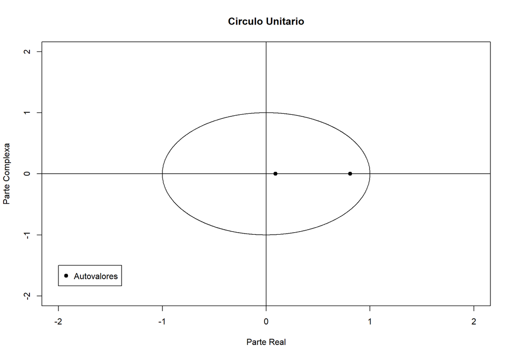

```r
# guardar autovalores do processo
autoval <- vars::roots(model1)

# Figura
x <- seq(-1,1,length = 1000)
y1 <- sqrt(1-x^2)
y2 <- -sqrt(1-x^2)
plot(c(x,x),c(y1,y2),xlab='Parte Real',ylab='Parte Complexa',type='l',main='Circulo Unitario',ylim=c(-2,2),xlim=c(-2,2))
abline(h = 0)
abline(v = 0)
points(autoval, Im(autoval),pch=19)
legend(-2.0,-1.5,legend="Autovalores",pch=19)
```

### 1.2.4 Função Impulso Resposta

Como visto, a modelagem VAR procura identificar a relação dinâmica existente em um conjunto previamente definido de variáveis.

Dentro desse tipo de abordagem, pode ser interessante para o pesquisador verificar o impacto de um **choque** ou **impulso** em uma variável sobre as outras.

Esse tipo de exercício é conhecido na literatura como **análise de impulso-resposta**. A ideia é verificar a resposta esperada na variável $y_{i,t+s}$ da mudança em uma unidade na variável $y_{j,t}$.

Em outras palavras, dá-se um choque em $t$ na variável $y_{j}$ e observa-se o efeito desse choque sobre a variável $y_{i}$ ao longo de $t+s$. Esses efeitos, ademais, podem ser acumulados.

Considere as equações já vistas anteriormente

$$y_{1,t}=\alpha_1-\delta_2y_{2,t}+\beta_1y_{1,t-1}+\beta_2y_{2,t-1}+\epsilon_{1,t}$$

$$y_{2,t}=\alpha_2-\delta_1y_{1,t}+\beta_2y_{2,t-1}+\beta_1y_{1,t-1}+\epsilon_{2,t}$$

Se forem reescritas na forma matriz como um processo de médias móveis, tem-se

$$\left[\begin{array}{c}
y_1 \\
y_2
\end{array}\right]_t = \left[\begin{array}{c}
\bar{y}_1 \\
\bar{y}_2
\end{array}\right] \sum_{i=0}^{\infty}B^i +\left[\begin{array}{c}
\epsilon_1 \\
\epsilon_2
\end{array}\right]_{t-1}$$
Como o termo de erro é dado por

$$\left[\begin{array}{c}
e_1 \\
e_2
\end{array}\right]_{t-1}= \frac{1}{1-\delta_1\delta_2}\left[\begin{array}{cc}
1 & -\delta_1\\
-\delta_2 & 1
\end{array}\right]\left[\begin{array}{c}
\epsilon_1 \\
\epsilon_2
\end{array}\right]_{t-1}$$

Se tem

$$\left[\begin{array}{c}
y_1 \\
y_2
\end{array}\right]_t = \left[\begin{array}{c}
\bar{y}_1 \\
\bar{y}_2
\end{array}\right]+
\frac{1}{1-\delta_1\delta_2}\sum_{i=0}^{\infty}B^i
\left[\begin{array}{cc}
1 & -\delta_1\\
-\delta_2 & 1
\end{array}\right]\left[\begin{array}{c}
\epsilon_1 \\
\epsilon_2
\end{array}\right]_{t-1}$$

Que pode ser rearranjado para

$$\left[\begin{array}{c}
y_1 \\
y_2
\end{array}\right]_t = \left[\begin{array}{c}
\bar{y}_1 \\
\bar{y}_2
\end{array}\right]+ \sum_{i=0}^{\infty} \left[\begin{array}{cc}
\phi_{1,1}(i) & \phi_{1,2}(i)\\
\phi_{2,1}(i) & \phi_{2,2}(i)
\end{array}\right]\left[\begin{array}{c}
\epsilon_1 \\
\epsilon_2
\end{array}\right]_{t-1}$$

Onde cada $\phi_{i,j}$ é uma função de impulso-resposta e seu gráfico é uma maneira prática de visualizar o comportamento de choques entre as variáveis do modelo.

Em modelos estáveis, espera-se que as respostas a esses choques, que chamam impulsos, convirjam para zero em tempo finito, preferencialmente em poucos lags.

Vale observar que $\phi_{i,j}(0)$, a resposta instantânea, é chamado de multiplicar de choque.

O gráfico de $\phi_{i,j}(t)$ é formado por uma sequência de valores de tempo (i.e, t=0,1,2,…,n) assumindo na ultima equação do slide anterior que $e_t=1$.

Dessa maneira, a interpretação se inicia assumindo um choque de uma unidade na variável j, com a respectiva resposta na variável “i” dada pelo comportamento gráfico.

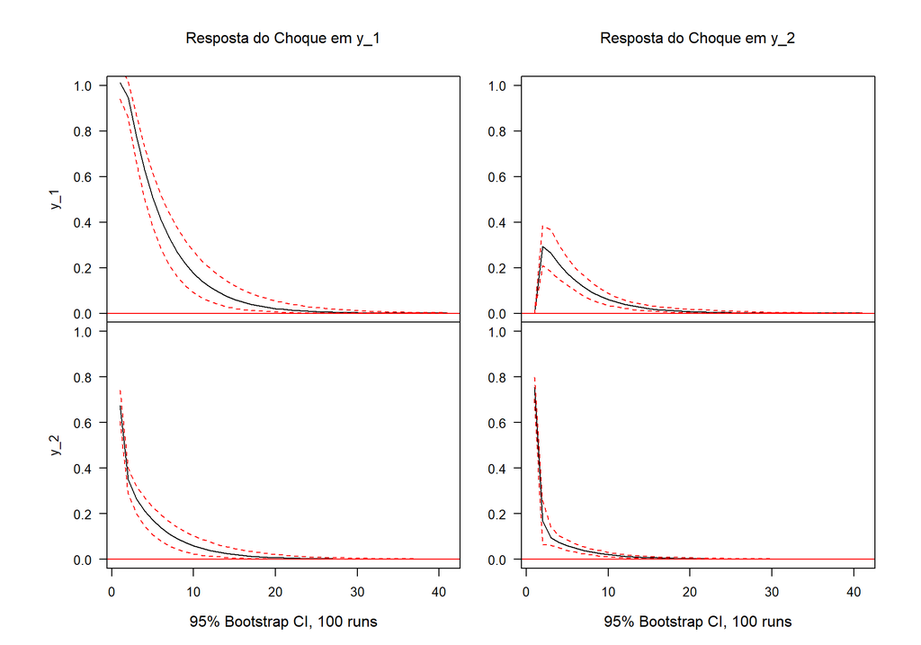

```r
# Função impulso-resposta
# FIR, PREVISAO E DECOMPOSICAO

# Elaboração da Figura

# resposta do choque em y1
model1.irf <- irf(model1, impulse = "y_1", n.ahead = 40, boot = TRUE)
# resposta do choque em y2
model2.irf <- irf(model1, impulse = "y_2", n.ahead = 40, boot = TRUE)

par(mfcol=c(2,2), mar=c(0,4,0,0), oma=c(5,3,5,3))

# Figura (a)
plot.ts(model1.irf$irf$y_1[,1], axes=F, oma.multi = c(0,0,5,0),
        ylab='y_1', ylim=c(-0,1))
lines(model1.irf$Lower$y_1[,1], lty=2, col='red')
lines(model1.irf$Upper$y_1[,1], lty=2, col='red')
axis(side=2, las=2, ylab='')
abline(h=0, col='red')
box()
mtext("Resposta do Choque em y_1", line = 2)

plot.ts(model1.irf$irf$y_1[,2], axes=F, oma.multi = c(0,0,5,0),
        ylab='y_2', ylim=c(-0,1))
lines(model1.irf$Lower$y_1[,2], lty=2, col='red')
lines(model1.irf$Upper$y_1[,2], lty=2, col='red')
axis(side=1, las=1)
axis(side=2, las=2)
abline(h=0, col='red')
box()
mtext("95% Bootstrap CI, 100 runs", side=1, line = 3)

# Figura (b)
plot.ts(model2.irf$irf$y_2[,1], axes=F, oma.multi = c(0,0,5,0),
        ylab='', ylim=c(-0,1))
lines(model2.irf$Lower$y_2[,1], lty=2, col='red')
lines(model2.irf$Upper$y_2[,1], lty=2, col='red')
axis(side=2, las=2, ylab='')
abline(h=0, col='red')
box()
mtext("Resposta do Choque em y_2", line = 2)

plot.ts(model2.irf$irf$y_2[,2], axes=F, oma.multi = c(0,0,5,0),
        ylab='', ylim=c(-0,1))
lines(model2.irf$Lower$y_2[,2], lty=2, col='red')
lines(model2.irf$Upper$y_2[,2], lty=2, col='red')
axis(side=1, las=1)
axis(side=2, las=2)
abline(h=0, col='red')
box()
mtext("95% Bootstrap CI, 100 runs", side=1, line = 3)
```

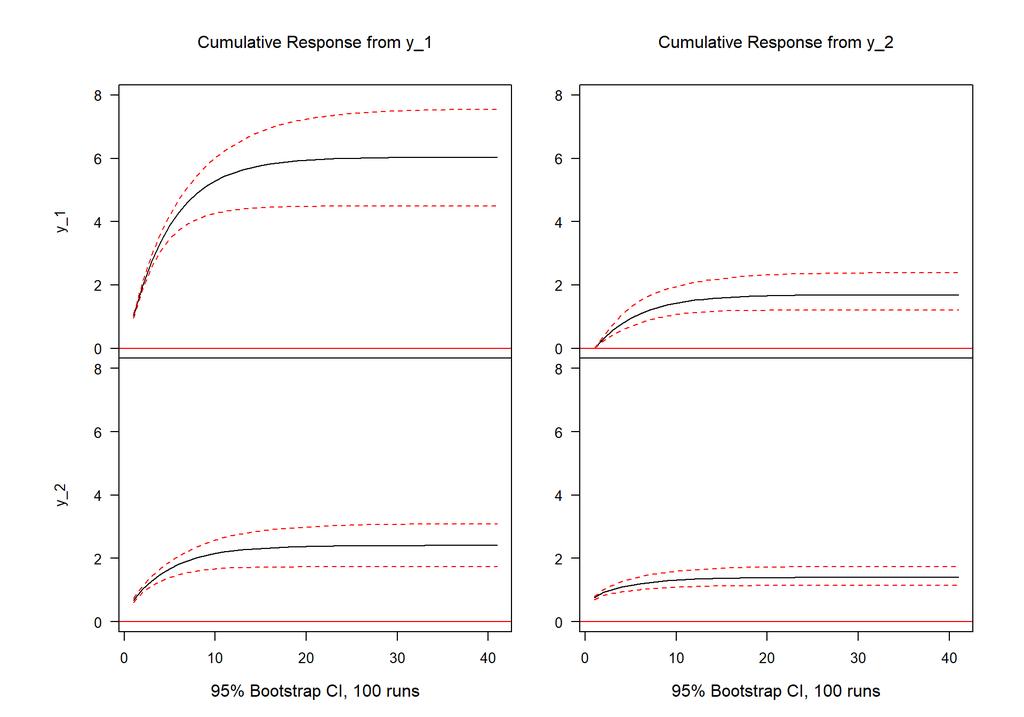

```r
# Elaboração da Figura

# resposta do choque em y1
model1.irf <- irf(model1, impulse = "y_1", n.ahead = 40, boot = TRUE, cumulative = T)
# resposta do choque em y2
model2.irf <- irf(model1, impulse = "y_2", n.ahead = 40, boot = TRUE, cumulative = T)

par(mfcol=c(2,2), mar=c(0,4,0,0), oma=c(5,3,5,3))

# Figura (a)
plot.ts(model1.irf$irf$y_1[,1], axes=F, oma.multi = c(0,0,5,0),
        ylab='y_1', ylim=c(-0,8))
lines(model1.irf$Lower$y_1[,1], lty=2, col='red')
lines(model1.irf$Upper$y_1[,1], lty=2, col='red')
axis(side=2, las=2, ylab='')
abline(h=0, col='red')
box()
mtext("Cumulative Response from y_1", line = 2)

plot.ts(model1.irf$irf$y_1[,2], axes=F, oma.multi = c(0,0,5,0),
        ylab='y_2', ylim=c(-0,8))
lines(model1.irf$Lower$y_1[,2], lty=2, col='red')
lines(model1.irf$Upper$y_1[,2], lty=2, col='red')
axis(side=1, las=1)
axis(side=2, las=2)
abline(h=0, col='red')
box()
mtext("95% Bootstrap CI, 100 runs", side=1, line = 3)

# Figura (b)
plot.ts(model2.irf$irf$y_2[,1], axes=F, oma.multi = c(0,0,5,0),
        ylab='', ylim=c(-0,8))
lines(model2.irf$Lower$y_2[,1], lty=2, col='red')
lines(model2.irf$Upper$y_2[,1], lty=2, col='red')
axis(side=2, las=2, ylab='')
abline(h=0, col='red')
box()
mtext("Cumulative Response from y_2", line = 2)

plot.ts(model2.irf$irf$y_2[,2], axes=F, oma.multi = c(0,0,5,0),
        ylab='', ylim=c(-0,8))
lines(model2.irf$Lower$y_2[,2], lty=2, col='red')
lines(model2.irf$Upper$y_2[,2], lty=2, col='red')
axis(side=1, las=1)
axis(side=2, las=2)
abline(h=0, col='red')
box()
mtext("95% Bootstrap CI, 100 runs", side=1, line = 3)
```

### 1.2.5 Decomposição da variância

Um último tópico importante é a decomposição de variância, isto é, o quanto da variância de uma variável do nosso conjunto é explicado pelas demais variáveis. No R, ela é implementada com a função `fevd`.

Em linhas gerais, a função retorna o quanto a variação (percentual) do erro de previsão é atribuída a cada variável para uma sequencia de valores no tempo.

A variância total dos erros de previsão é decomposta em duas componentes, neste caso em análise, uma relacionada com $y_1$ e a outra com $y_2$.

Na prática, esta análise nos ajuda a verificar quais variáveis são realmente importantes quando o objetivo é realizar previsões.

Quanto maior for a contribuição percentual de uma variável para a variação total da outra, mais importante ela é para se realizar boas previsões da variável da qual realiza-se a decomposição.

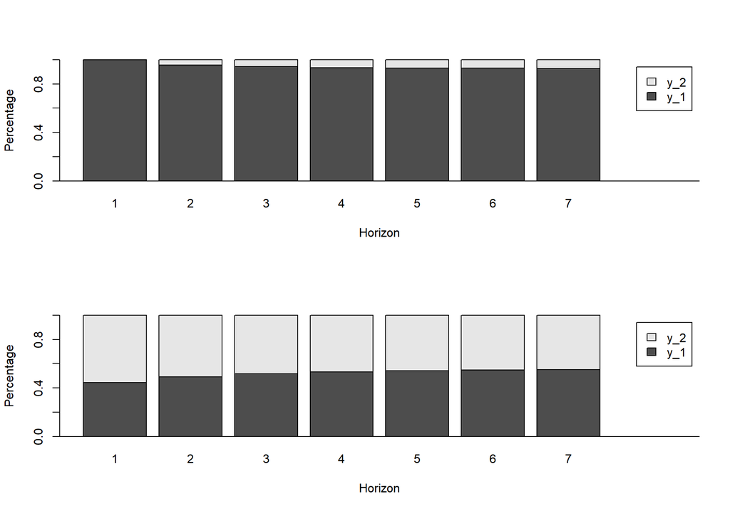

```r
# Decomposição da variância

fevd.model1 <- fevd(model1, n.ahead = 7)
plot(fevd.model1, main="")
```

## 1.3 Previsão no Modelo VAR

No R, duas maneiras para gerar previsões estão implantadas em predict() e fanchart(), a primeira retorna os pontos médios dos intervalos de confiança para cada previsão enquanto a segunda produz os intervalos como áreas sombreadas.

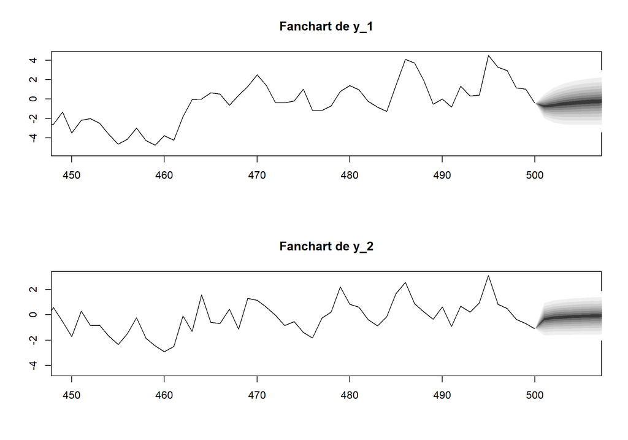

```r
# Previsões

#  previsão a partir de 'fanchart'
model1.y_1 <- predict(model1, n.ahead = 10, ci = 0.95)
fanchart(model1.y_1, xlim = c(450,505), main = c("Fanchart de y_1", "Fanchart de y_2"))
```

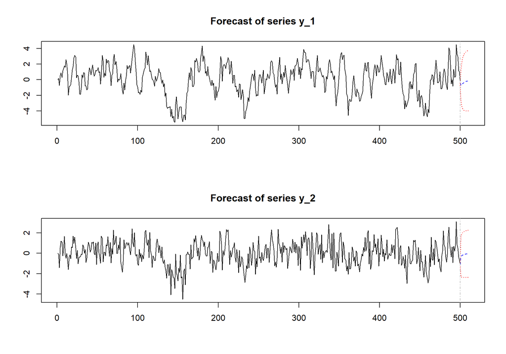

```r
plot(model1.y_1)
```

## 1.4 Teste de Causalidade de Granger

O termo “causalidade de Granger” significa que há uma relação de antecedência-defasagem entre as variáveis de séries de tempo multivariadas. Em outras palavras, uma variável x vai ser dita que causa Granger em uma variável y, se os valores passados de x e valores passados de y forem úteis para prever y.

Testa se uma variável endógena pode ser tratada como exógena. Para cada equação do VAR, é calculado uma estatística de $\chi^2$ para a significância conjunta de cada uma das variáveis endógenas defasadas na equação.

A estimação do VAR deve ser feita antes do teste de causalidade de Granger, uma vez que a análise está verificando a causalidade entre várias variáveis.

Testa-se a hipótese nula de que os coeficientes estimados da variável exogena defasada são conjuntamente iguais à zero. Não rejeitar essa possibilidade é equivalente a não rejeitar a hipótese de que a variável Y não causa a Granger a variável X.

São estimadas regressões bivariadas na forma:

$$y_t=\alpha_{0}+\alpha_{1}y_{t-1}+\dots+\beta_1x_{t-1}+\dots+\varepsilon_t$$

$$x_t=\alpha_{0}+\alpha_{1}x_{t-1}+\dots+\beta_1y_{t-1}+\dots+\mu_t$$
para todos os possíveis pares de variáveis endógenas. O teste realizado conjuntamente, para cada equação, é:

$$\beta_1=\beta_2=\dots=0$$

As hipóteses nulas são que x não causa a Granger y na primeira equação e que y não causa a Granger x na segunda regressão.

```r
# Causalidade de Granger
causality(model1)$Granger
```

```
#
#   Granger causality H0: y_1 do not Granger-cause y_2
#
# data:  VAR object model1
# F-Test = 34.861, df1 = 1, df2 = 994, p-value = 4.857e-09
```